# R project: SLR and Bootstrap

Sujata Sahu

11th Dec 2022

# Introduction:

In this project I have to create the following two unique functions: Simple linear Regression(SLR) function:It is defined as myslr() and creates estimates betas in a slr. Bootstrap Function:It is defined as myboot() and creates bootstrap esimates from a sample.

# Data

We will all apply our function to the mtcars data set and make a linear model `mpg ~ wt`

Describe the data The data Motor Trend Car Road Test was extracted from the 1974 Motor Trend US magazine and it is comprises fuel consumption and 10 aspects of automobile design and performancee for 32 automoboiles. Describe the nature and type of the variables. The data contain the following variables: 1. mpg - Miles/(US) gallon 2. cyl - Number of cylinders 3. disp - Displacement (cu.in.) 4. hp - Gross horsepower 5. drat - Rear axle ratio 6. wt - Weight (1000 lbs) 7. qsec - 1/4 mile time 8. vs - Engine (0 = V-shaped, 1 = straight) 9. am - Transmission (0 = automatic, 1 = manual) 10. gear - Number of forward gears 11. carb - Number of carburetors There are 11 variables total, all of which are numerical. The 11 variables are all of the double type,from which 9 are quantitative and 2 qualitative. “vs” and “am” are qualitative variables and have nominal values where as the rest are quantitative.

Plot the data – be very creative and interpret the plots

```r
data(mtcars)
head(mtcars)
```

```
##                    mpg cyl disp  hp drat    wt  qsec vs am gear carb
## Mazda RX4         21.0   6  160 110 3.90 2.620 16.46  0  1    4    4
## Mazda RX4 Wag     21.0   6  160 110 3.90 2.875 17.02  0  1    4    4
## Datsun 710        22.8   4  108  93 3.85 2.320 18.61  1  1    4    1
## Hornet 4 Drive    21.4   6  258 110 3.08 3.215 19.44  1  0    3    1
## Hornet Sportabout 18.7   8  360 175 3.15 3.440 17.02  0  0    3    2
## Valiant           18.1   6  225 105 2.76 3.460 20.22  1  0    3    1
```

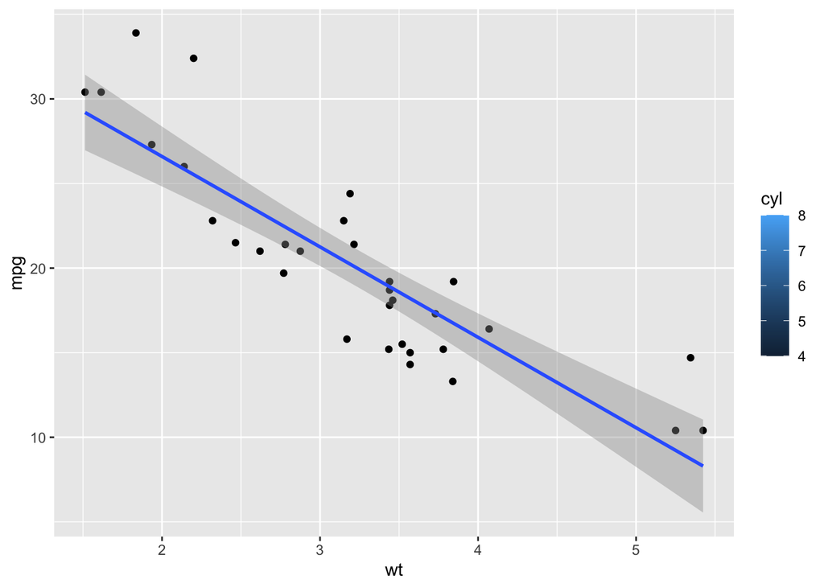

```r
library(ggplot2)

g1 = ggplot(mtcars, aes(x = wt, y=mpg, fill = cyl)) + geom_point() + geom_smooth(method="lm", formula=y~x)
g2 = ggplot(mtcars, aes(x = vs, y=mpg, fill = cyl)) + geom_point() + geom_smooth(method="lm", formula=y~x)
g3 = ggplot(mtcars, aes(x = cyl, y=disp)) + geom_point() + geom_smooth(method="lm", formula=y~x)
g1
```

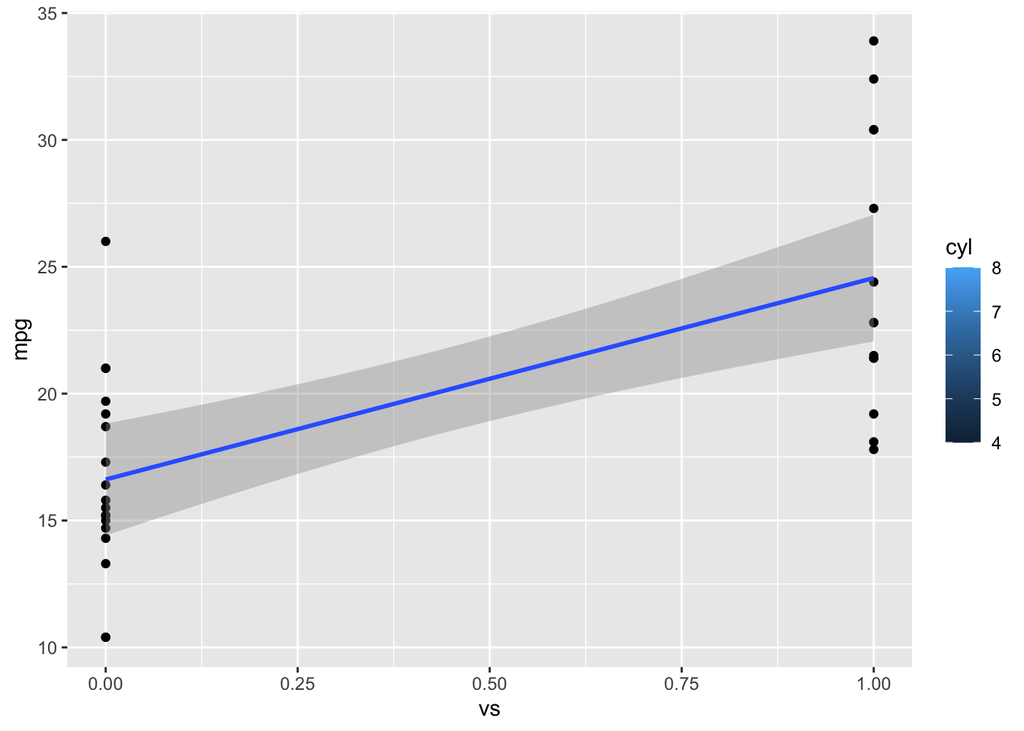

```r
g2
```

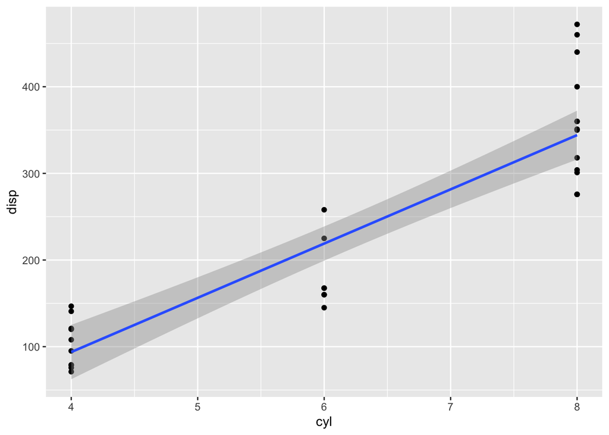

```r
g3
```

# Theory used

Give the mathematical formulae in Latex.
$$y_i = \beta_1 + \beta_2 x_i + \epsilon_i$$
Interpret the meaning of the symbols. Where: 1.y_i is the dependent variable or criterion variable 2.x_i is the independent variable or predictor variable 3.beta_1 is the y-intercept,
4.beta_2 is the slope of the line and epsilon_i is the error for a given combination of x_i and y_i

$$\epsilon_i \sim N(o,\sigma^2)$$
$\epsilon_i$ holds many assumptions specific to the model and is independently and identically distributed in the Normal of 0 and Sigma square.

# Application of SLR to the mtcars data set

Use R to analysze the data As it is given that we have to make a linear model between “wt” and “mpg” replaced x = wt and y = mpg

```r
y.lm=lm(mpg~wt,data=mtcars)
y.lm
```

```
##
## Call:
## lm(formula = mpg ~ wt, data = mtcars)
##
## Coefficients:
## (Intercept)           wt
##      37.285       -5.344
```

So the values of beta_1 and beta_2 are as follows 1.beta_1 = 37.285$ (y-intercept) 2.beta_2 = -5.344$ (slope)

Check assumptions

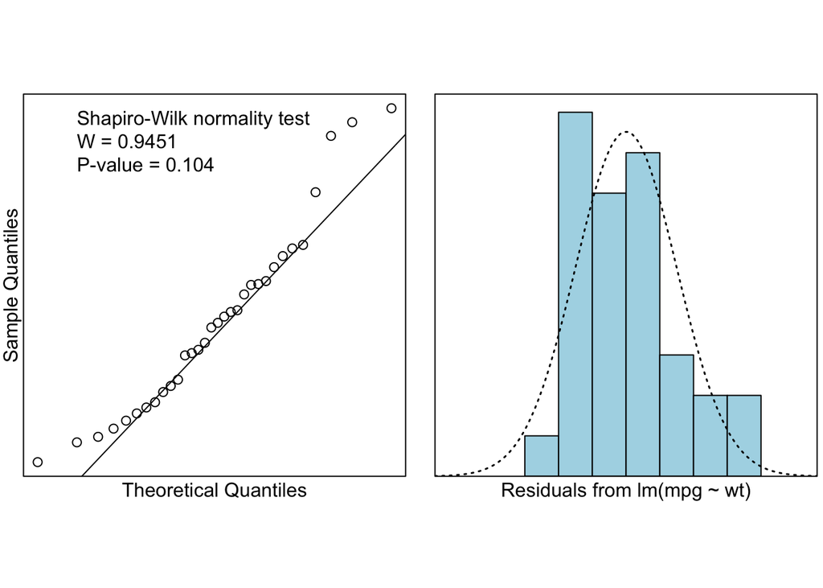

```r
require(s20x)
library(s20x)

normcheck(y.lm,shapiro.wilk=TRUE)
```

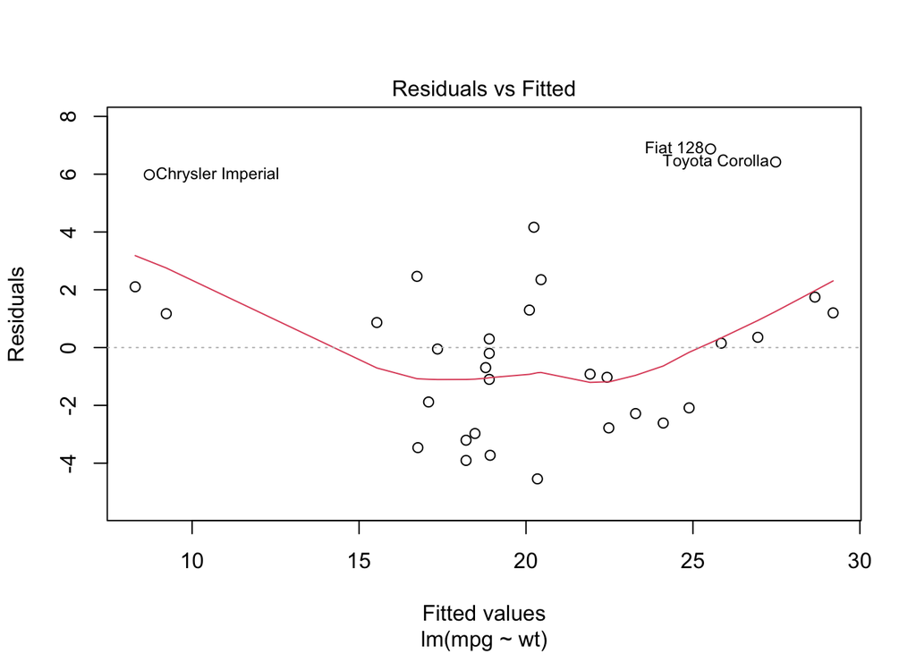

```r
plot(y.lm, which =1)
```

Interpret the summary output.

```r
summary(y.lm)
```

```
##
## Call:
## lm(formula = mpg ~ wt, data = mtcars)
##
## Residuals:
##     Min      1Q  Median      3Q     Max
## -4.5432 -2.3647 -0.1252  1.4096  6.8727
##
## Coefficients:
##             Estimate Std. Error t value Pr(>|t|)
## (Intercept)  37.2851     1.8776  19.858  < 2e-16 ***
## wt           -5.3445     0.5591  -9.559 1.29e-10 ***
## ---
## Signif. codes:  0 '***' 0.001 '**' 0.01 '*' 0.05 '.' 0.1 ' ' 1
##
## Residual standard error: 3.046 on 30 degrees of freedom
## Multiple R-squared:  0.7528, Adjusted R-squared:  0.7446
## F-statistic: 91.38 on 1 and 30 DF,  p-value: 1.294e-10
```

```r
ciReg(y.lm)
```

```
##             95 % C.I.lower    95 % C.I.upper
## (Intercept)       33.45050          41.11975
## wt                -6.48631          -4.20263
```

# interpretion of summary output

The first summary parameter is residual which is calculated as the difference of predicted y value to the actual y value.Checking out the results we can see that the variation ranges from -4.5432 to 6.8727 and almost 50% of the values lie between -2.3647 and 1.4096.The next parameter that is the coefficients which tells about the standard deviation,tvalue and probability for null hypothesis.Standard error returned as 0.5591, and the value of t is far away from zero which shows a relationship between wt and mpg. The standard deviation of the regression that is the residual standard error , correlation coefficient, test statistic for F-test and p-value helps to know how well our data fits for the regression. We got a value for RSE as 3.046 which is the the difference in the true value aand observed value is approximately 3.046, 0.7446 as adjusted R squared tells that the most of the portion of the variablity in outcome can be explained by regression.The next parameter F-statistic helps to assess if atleast one predictor variable has a non zero coefficient, the value we got for f statistic is 91.38 and the corresponding p-value is 1.294e-10.According to the statistic the higher the F values lower the p value(p<0.05). And our model shows the required stats that means linaer regression is a good fit for our data.

##Confidence Interval The results shows the function gives the 95% confidence intercepts for the fitted model. The value of for $\beta_0$ (intercept) is 33.45050 and 41.11975 and for $\beta_1$ is -6.48631 and -4.20263

# Now making my own Simple Linear Regression function(SLR function):

```r
myslr <- function(x, y,df){
  y.lm = lm(y ~ x) #creates linear regression
  sum = summary(y.lm) #shows summary
  n = normcheck(y.lm, shapiro.wilk = T) #normalisationcheck
  ci= ciReg(y.lm) #gives confidence interval
  gp = ggplot(df, aes(x = x, y = y)) + geom_point() + geom_smooth(method = 'lm', formula = y~x) #plots the graph using aesthetics as x and y
  ggsave('SLRplot.jpeg',plot = gp, dpi = 300)
  pl = (list(n,gp))
  op<-capture.output(summary(y.lm), file=NULL,append=FALSE)
  op_df <-as.data.frame(op)
  write.csv(op_df,'Summarypredictiondata.csv')
  return(list("summary" = sum, coefficients = ci, plot = pl))
}
```

# Invoking my slr function

```r
myslrfunc= myslr(x=mtcars$wt,y=mtcars$mpg, df=mtcars)
```

```
##             95 % C.I.lower    95 % C.I.upper
## (Intercept)       33.45050          41.11975
## x                 -6.48631          -4.20263
```

[figure not shown]

```r
myslrfunc
```

```
## $summary
##
## Call:
## lm(formula = y ~ x)
##
## Residuals:
##     Min      1Q  Median      3Q     Max
## -4.5432 -2.3647 -0.1252  1.4096  6.8727
##
## Coefficients:
##             Estimate Std. Error t value Pr(>|t|)
## (Intercept)  37.2851     1.8776  19.858  < 2e-16 ***
## x            -5.3445     0.5591  -9.559 1.29e-10 ***
## ---
## Signif. codes:  0 '***' 0.001 '**' 0.01 '*' 0.05 '.' 0.1 ' ' 1
##
## Residual standard error: 3.046 on 30 degrees of freedom
## Multiple R-squared:  0.7528, Adjusted R-squared:  0.7446
## F-statistic: 91.38 on 1 and 30 DF,  p-value: 1.294e-10
##
##
## $coefficients
##             95 % C.I.lower    95 % C.I.upper
## (Intercept)      33.450500         41.119753
## x                -6.486308         -4.202635
##
## $plot
## $plot[[1]]
## NULL
##
## $plot[[2]]
```

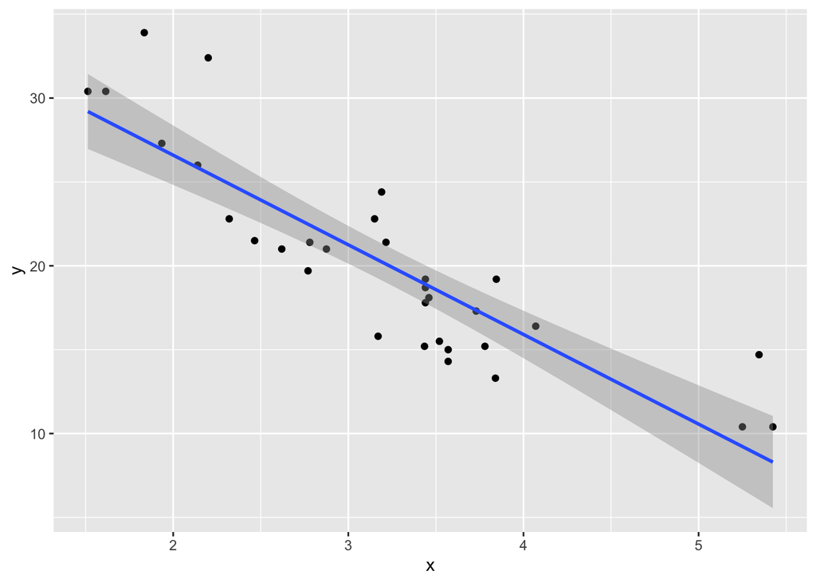

What are the point and interval estimates?

[output not shown]

# BootStrap

Make a function `myboot` that will create bootstrap estimates from a sample. The parameter estimated will be the population variance $\sigma^2$ of mpg for 4 cylinder cars. Though the function will be entirely general.

```r
myboot = function(x, alpha=0.05, fun="var")
{
  n = length(x)  #to determine the variable's length
  Iterator = 5000  #to provide a sample 5000 times the length of the input variable
  y = sample(x, n*Iterator, replace = TRUE)
  boot.m = matrix(y, nrow = n, ncol = Iterator, byrow = TRUE)
  xStat = apply(boot.m,2, "var")
  q= quantile(xStat, c(alpha/2, 1-alpha/2))
  histboot = hist(xStat, freq = FALSE,las = 1, main = paste("Histogram of Booststap sample","\n", "alpha = ", alpha, "iterations = ", Iterator, sep = " ", plot = T))
  write.csv(as.data.frame(boot.m),"simulation.csv")
  return(list(quantile = q, plot = histboot))
}
```

# Invoking the function

```r
dt= subset(mtcars, cyl == 4,  select = mpg)
mybootstrapfunc = myboot(x= data.matrix(dt), alpha = 0.05)
```

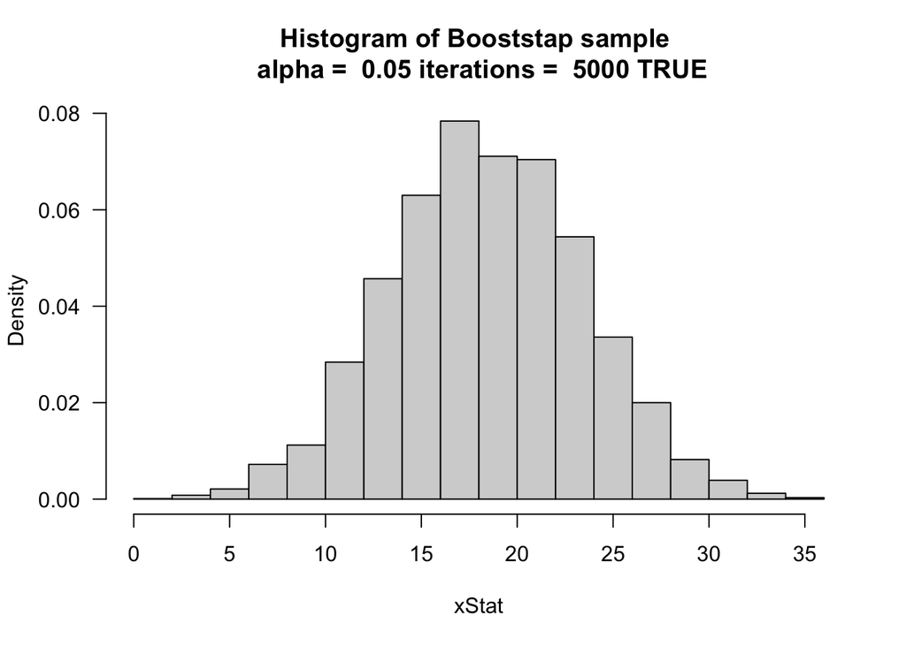

```r
mybootstrapfunc
```

```
## $quantile
##      2.5%     97.5%
##  8.505586 28.089141
##
## $plot
## $breaks
##  [1]  0  2  4  6  8 10 12 14 16 18 20 22 24 26 28 30 32 34 36
##
## $counts
##  [1]   1   8  21  72 112 284 457 630 784 711 704 544 336 200  82  39  12   3
##
## $density
##  [1] 0.0001 0.0008 0.0021 0.0072 0.0112 0.0284 0.0457 0.0630 0.0784 0.0711
## [11] 0.0704 0.0544 0.0336 0.0200 0.0082 0.0039 0.0012 0.0003
##
## $mids
##  [1]  1  3  5  7  9 11 13 15 17 19 21 23 25 27 29 31 33 35
##
## $xname
## [1] "xStat"
##
## $equidist
## [1] TRUE
##
## attr(,"class")
## [1] "histogram"
```